# DATA 606 Data Project

John Grando

May 1, 2017

## Grando - Data Project Proposal

```r
# Set the working directory and read in the files
if (Sys.info()["sysname"] == "Windows") {
    setwd("~/Masters/DATA606/DataProject")
} else {
    setwd("~/Documents/Masters/DATA606/DataProject")
}
fileurl = "PublicLEEDProjectDirectory.csv"
project_data <- read.csv(file = fileurl, header = TRUE, sep = ",", stringsAsFactors = FALSE)
svfileurl = "SummaryVersionsMap.csv"
sv_data <- read.csv(file = svfileurl, header = TRUE, sep = ",", stringsAsFactors = FALSE)
# Format dates
project_data$CertDate <- as.Date(project_data$CertDate, "%m/%d/%Y")
project_data$RegistrationDate <- as.Date(project_data$RegistrationDate, "%m/%d/%Y")
# Add two calculated columns.  SubtmittalTime is the number of days between certification
# and registration dates (completed projects).  SubmittalTimePending is the number of days
# between the date the information was pulled and the registration date (open projects).
project_data$SubmittalTime <- as.numeric(project_data$CertDate - project_data$RegistrationDate)
latest_date <- max(project_data$RegistrationDate, na.rm = TRUE)
project_data$SubmittalTimePending <- ifelse(is.na(project_data$CertDate) == TRUE, latest_date -
    project_data$RegistrationDate, NA)
# Run sapply() to do a table join between the project directory data and the
# SummaryVersionsMap file.  The latter file is a mapping scheme that provides further
# sub-category information to each project type.
project_data$RatingSystemFamily <- sapply(project_data$LEEDSystemVersionDisplayName, function(x) {
    x <- sv_data[which(sv_data$RatingSystem == x), 2]
    x <- ifelse(identical(x, character(0)), character(0), as.character(x))
})
project_data$System <- sapply(project_data$LEEDSystemVersionDisplayName, function(x) {
    x <- sv_data[which(sv_data$RatingSystem == x), 3]
    x <- ifelse(identical(x, character(0)), character(0), as.character(x))
})
project_data$Version <- sapply(project_data$LEEDSystemVersionDisplayName, function(x) {
    x <- sv_data[which(sv_data$RatingSystem == x), 4]
    x <- ifelse(identical(x, character(0)), character(0), as.character(x))
})
project_data$Platform <- sapply(project_data$LEEDSystemVersionDisplayName, function(x) {
    x <- sv_data[which(sv_data$RatingSystem == x), 5]
    x <- ifelse(identical(x, character(0)), character(0), as.character(x))
})
project_data$RSLaunch <- sapply(project_data$LEEDSystemVersionDisplayName, function(x) {
    x <- sv_data[which(sv_data$RatingSystem == x), 6]
})
project_data$RSLaunch <- as.Date(as.character(project_data$RSLaunch), "%m/%d/%Y")
project_data$RSRegClose <- sapply(project_data$LEEDSystemVersionDisplayName, function(x) {
    x <- sv_data[which(sv_data$RatingSystem == x), 7]
})
project_data$RSRegClose <- as.Date(as.character(project_data$RSRegClose), "%m/%d/%Y")
project_data$RSSunset <- sapply(project_data$LEEDSystemVersionDisplayName, function(x) {
    x <- sv_data[which(sv_data$RatingSystem == x), 8]
})
project_data$RSSunset <- as.Date(as.character(project_data$RSSunset), "%m/%d/%Y")
project_data$RSIteration <- sapply(project_data$LEEDSystemVersionDisplayName, function(x) {
    x <- sv_data[which(sv_data$RatingSystem == x), 9][1]
})
project_data$RSIteration <- as.integer(project_data$RSIteration)

# Add a few more calculated columns now that the sub-category data has been added.
project_data$RegAfterLaunch <- as.integer(project_data$RegistrationDate - project_data$RSLaunch)
project_data$CertAfterLaunch <- as.integer(project_data$CertDate - project_data$RSLaunch)
project_data$RegYear <- trunc(project_data$RegAfterLaunch/365) + 1
project_data$CertYear <- trunc(project_data$CertAfterLaunch/365) + 1

# Create more generalized categories of the Owner types.
project_data$OwnerTypesAdj <- sapply(project_data$OwnerTypes, function(x) {
    x <- ifelse(grepl("government", tolower(x)), "government", ifelse(grepl("education", tolower(x)),
        "education", ifelse(grepl("confidential", tolower(x)), "confidential", ifelse(grepl("corporate",
            tolower(x)), "corporate", ifelse(grepl("^profit", tolower(x)), "profit", ifelse(grepl("^non-profit",
            tolower(x)), "non-profit", ifelse(grepl("individual", tolower(x)), "individual",
            ifelse(grepl("investor", tolower(x)), "investor", ifelse(x == "", "other", ifelse(is.null(x),
                "other", "other"))))))))))
})

# Days the v3 platform has been open since launch
maxv3days <- as.numeric(latest_date - as.Date("4/27/2009", "%m/%d/%Y"))

project_data_adjusted <- project_data
# If a v2 project is pending longer than the maximum amount of days v3 has been open, then
# change the length to that time
project_data_adjusted$SubmittalTimePending <- ifelse(project_data_adjusted$Platform == "v2" &
    project_data_adjusted$SubmittalTimePending > maxv3days, maxv3days, project_data_adjusted$SubmittalTimePending)
# If it took a v2 project to certify longer than the maximum amount of v3 days, then we
# will consider it an open project with the maximum v3 days of pending time.
project_data_adjusted$SubmittalTimePending <- ifelse(project_data_adjusted$Platform == "v2" &
    project_data_adjusted$SubmittalTime > maxv3days, maxv3days, project_data_adjusted$SubmittalTimePending)
# For the same issue noted above, make sure the SubmittalTime column (days the project was
# registered before being certified) returns an NA for theses projects.
project_data_adjusted$SubmittalTime <- ifelse(project_data_adjusted$Platform == "v2" & project_data$SubmittalTime >
    maxv3days, NA, project_data_adjusted$SubmittalTime)

# Make sure all columns have good data and that v4, ND, and Homes projects are excluded due
# to small size.
completed_projects <- subset(project_data_adjusted, project_data_adjusted$SubmittalTime > 0 &
    !(is.na(project_data_adjusted$CertDate)) & !(identical(project_data_adjusted$RatingSystemFamily,
    character(0))) & !(is.na(project_data_adjusted$RatingSystemFamily)) & !(project_data_adjusted$RatingSystemFamily ==
    "ND") & !(project_data_adjusted$RatingSystemFamily == "Homes") & !(project_data_adjusted$Platform ==
    "v4") & project_data_adjusted$GrossSqFoot > 0)

# Same as above but with projects that have not certified.
open_projects <- subset(project_data_adjusted, project_data_adjusted$SubmittalTimePending >
    0 & is.na(project_data_adjusted$CertDate) & !(identical(project_data_adjusted$RatingSystemFamily,
    character(0))) & !(is.na(project_data_adjusted$Platform)) & !(project_data_adjusted$RatingSystemFamily ==
    "ND") & !(project_data_adjusted$RatingSystemFamily == "Homes") & !(project_data_adjusted$Platform ==
    "v4") & project_data_adjusted$GrossSqFoot > 0)
```

### Part 1 - Introduction:

LEED is a framework for identifying, implementing, and measuring green building and neighborhood design, construction, operations, and maintenance. The United States Green Building Council provides publicly available data that identifies all LEED Certified buildings. This list is known as the LEED Project Directory (http://www.usgbc.org/projects/) and features non-confidential projects under each LEED rating system. Once the project has been certified, its team is invited to submit content to update their profile, which contains basic project details, an overview on how the project achieved sustainability using LEED, and a photo slideshow. Project teams also have the option of linking to a video of their LEED building and a relevant website.

Generally, LEED projects register near the beginning of a building’s design phase (the drawing/planning stage). After preparing documentation, and after the construction phase (the building stage) ends, the project team will have their project certified by the Green Business Certification Inc. (GBCI). GBCI is the only certification and credentialing body within the green business and sustainability industry to exclusively administer project certifications and professional credentials of LEED, EDGE, PEER, WELL, SITES, GRESB, Parksmart and Zero Waste. The data available on this LEED Project Directory (http://www.usgbc.org/project-download-all) is a summary of every LEED registered project. Each project can be broken down into further subcategories, such as Rating System Families, based on the type of Certification. While this data is not directly accessible in a single file, the relations can be created from multiple locations on the website.

Within the company, it is important to be able to predict the number of days it takes for a project to certify (from the time it was regiestered) in order to coordinate employee time commitments to perform certification work. Additionally, it is essential that any variables which signficantly affect this time period (submittal time) be identified so that if there is a shift in submittals for one group, the company is aware of the future impacts. By having the ability to predict the length of time it takes for projects to certify, the GBCI can forecast their needs and manage the review staff as needed.

### Part 2 - Data:

Upon registering a LEED project, the information in this data set is populated as a part of the requirments of the LEED process. Each case represents a registered LEED project.

The project data is collected by the United States Green Building Council and is available online here: http://www.usgbc.org/project-download-all. The version mapping table, used to break projects down into sub-categories, is not publicly available in a single format. however, all the infomration needed to create this data set is available on http://www.usgbc.org.

There are 126237 observations in the overall data set. The data consist of projects which are registered under different Platforms (v2 and v3 are analyzed for this study). These platforms are created in a sequential manner which means that v2 is an older version than v3. In order to normalize for this issue, v2 projects that were pending longer than the maximum amount of days v3 has been open are considered to have never become certified and remained open for the same amount of time as the maximum number of days v3 has been open. After filtering to projects with sufficient information, and pertinent categories, there are 67694 observations.  
This is an observational study because it is based on past, and current, data which we have not influenced in any manner and are only evaluating the results.

The population of interest is all future project buildings which will register for LEED Certification. Given that this data actually represents the entire current population, it is assumed that this analysis can be generalized to future projects. Some issues that may cause a discrepancy between this analysis and the time it takes future projects to certify could include the following; changes to the LEED Rating System requirements, expansion into new building markets that are unfamiliar with referenced procedures and protocols, market acclimation to the standard (which may speed up certification time), and new Rating System Families or altenrative compliance paths to Certification.

The response variable chosen is number of days between a project’s registration and certification date (SubmittalTime). This is a discrete numerical value. After a preliminary analysis, shown in the next section, the explanatory variables chosen for this study are the rating system families (categorical, nominal) and gross floor area (numerical, continuous).

Since this is an observational study, we cannot determine causal connections between the variables of interest. We will only be able to determine whether the variables of interest are associated or not.

### Part 3 - Exploratory data analysis:

I have prepared a data set which includes calculations that determine the length of time it took for each project to certify. Since v3 projects can only have been open for 2871 days, v2 projects (previous version) which were certified after 2871 days were considered to be un-certified.

```r
require(ggplot2)
#### Graphs based on present assumptions
table(completed_projects$RatingSystemFamily)
```

```
##
##   BDC   IDC    OM
## 20419  8183  4983
```

```r
table(completed_projects$Platform)
```

```
##
##    v2    v3
## 14329 19256
```

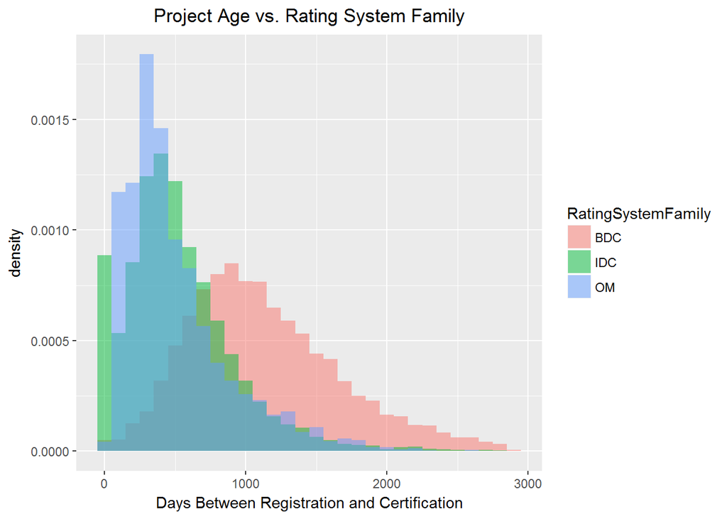

```r
# General Rating System Family histogram
ggplot(completed_projects, aes(x = SubmittalTime, fill = RatingSystemFamily)) + geom_histogram(binwidth = 100,
    alpha = 0.5, position = "identity", aes(y = ..density..)) + labs(x = "Days Between Registration and Certification") +
    ggtitle("Project Age vs. Rating System Family") + theme(plot.title = element_text(hjust = 0.5))
```

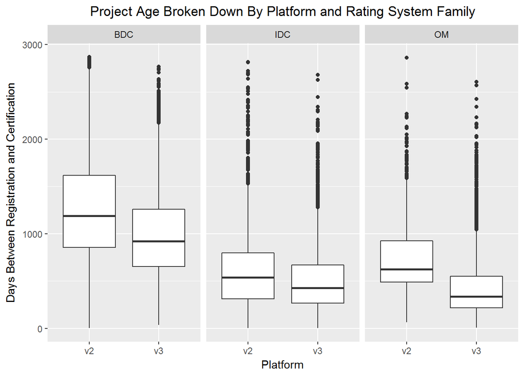

```r
# General Platform ~ Rating System Family boxplot
ggplot(completed_projects, aes(y = SubmittalTime, x = Platform)) + geom_boxplot() + facet_wrap(~RatingSystemFamily) +
    labs(y = "Days Between Registration and Certification") + ggtitle("Project Age Broken Down By Platform and Rating System Family") +
    theme(plot.title = element_text(hjust = 0.5))
```

```r
# Summary Tables
tabledata <- subset(completed_projects, completed_projects$RatingSystemFamily == "BDC")
summary(tabledata$SubmittalTime)
```

```
##    Min. 1st Qu.  Median    Mean 3rd Qu.    Max.
##       2     744    1055    1132    1450    2870
```

```r
sd(tabledata$SubmittalTime)
```

```
## [1] 537.2698
```

```r
tabledata <- subset(completed_projects, completed_projects$RatingSystemFamily == "IDC")
summary(tabledata$SubmittalTime)
```

```
##    Min. 1st Qu.  Median    Mean 3rd Qu.    Max.
##     1.0   274.0   462.0   528.7   711.0  2814.0
```

```r
sd(tabledata$SubmittalTime)
```

```
## [1] 387.4607
```

```r
tabledata <- subset(completed_projects, completed_projects$RatingSystemFamily == "OM")
summary(tabledata$SubmittalTime)
```

```
##    Min. 1st Qu.  Median    Mean 3rd Qu.    Max.
##     6.0   255.0   406.0   510.1   657.0  2860.0
```

```r
sd(tabledata$SubmittalTime)
```

```
## [1] 380.7195
```

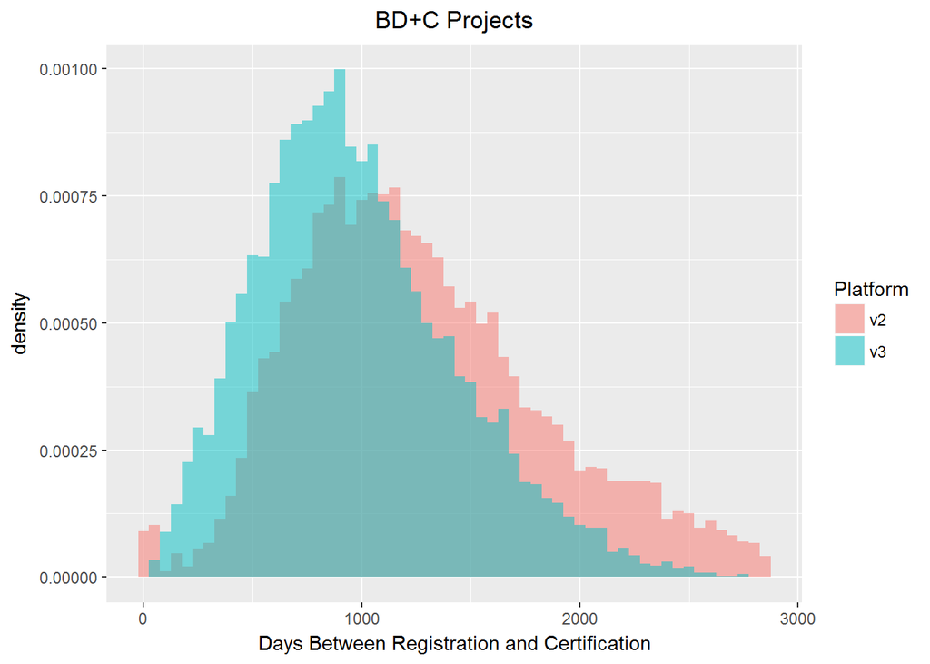

```r
#### Rating System Family Tests
completed_projects_BDC <- subset(completed_projects, completed_projects$RatingSystemFamily ==
    "BDC")
ggplot(completed_projects_BDC, aes(x = SubmittalTime, fill = Platform)) + geom_histogram(binwidth = 50,
    alpha = 0.5, position = "identity", aes(y = ..density..)) + labs(x = "Days Between Registration and Certification") +
    ggtitle("BD+C Projects") + theme(plot.title = element_text(hjust = 0.5))
```

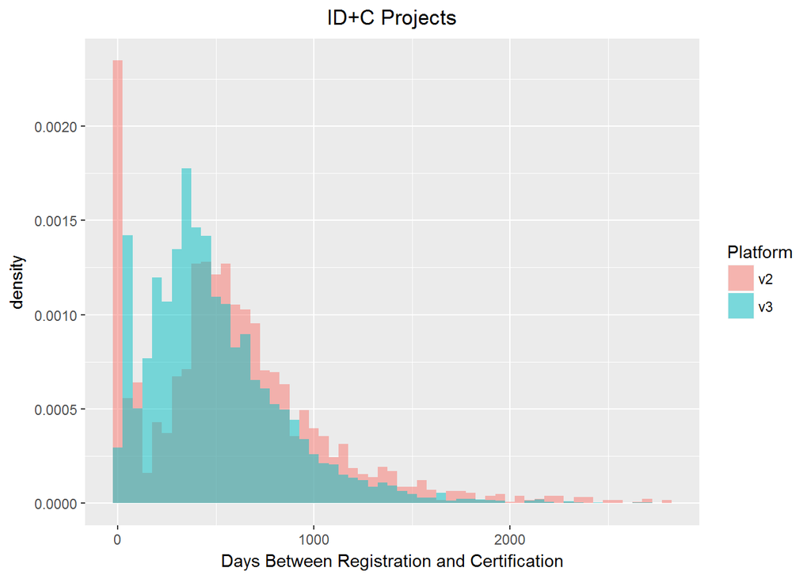

```r
completed_projects_IDC <- subset(completed_projects, completed_projects$RatingSystemFamily ==
    "IDC")
ggplot(completed_projects_IDC, aes(x = SubmittalTime, fill = Platform)) + geom_histogram(binwidth = 50,
    alpha = 0.5, position = "identity", aes(y = ..density..)) + labs(x = "Days Between Registration and Certification") +
    ggtitle("ID+C Projects") + theme(plot.title = element_text(hjust = 0.5))
```

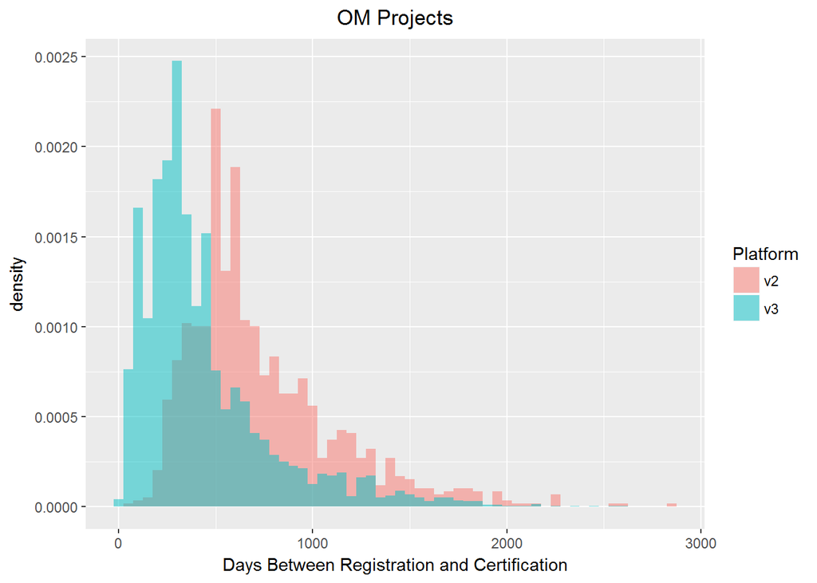

```r
completed_projects_OM <- subset(completed_projects, completed_projects$RatingSystemFamily ==
    "OM")
ggplot(completed_projects_OM, aes(x = SubmittalTime, fill = Platform)) + geom_histogram(binwidth = 50,
    alpha = 0.5, position = "identity", aes(y = ..density..)) + labs(x = "Days Between Registration and Certification") +
    ggtitle("OM Projects") + theme(plot.title = element_text(hjust = 0.5))
```

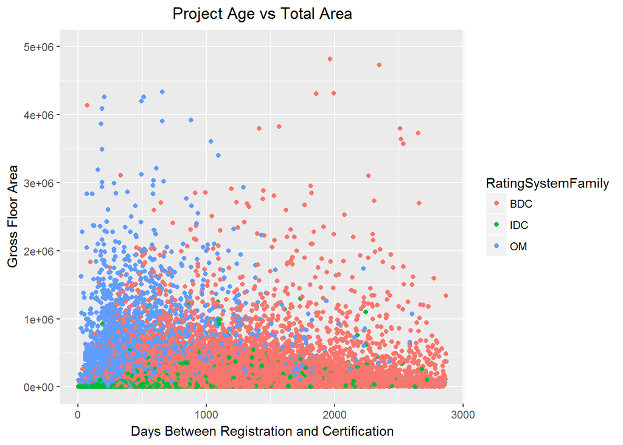

```r
#### Gross floor area vs. submittal time tests

# I have scaled the y axis to exclude some outliers in favor of seeing the main data set
# more clearly

ggplot(completed_projects, aes(y = GrossSqFoot, x = SubmittalTime, color = RatingSystemFamily)) +
    geom_point() + scale_y_continuous(limits = c(0, 5e+06)) + labs(x = "Days Between Registration and Certification",
    y = "Gross Floor Area") + ggtitle("Project Age vs Total Area") + theme(plot.title = element_text(hjust = 0.5))
```

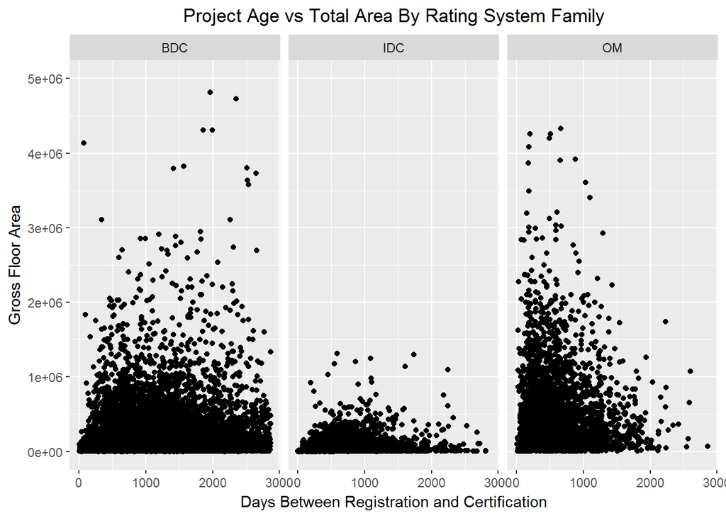

```r
# When a facet wrap is applied, it is a little more clear there may be some association
# with at least one rating system.

ggplot(completed_projects, aes(y = GrossSqFoot, x = SubmittalTime)) + geom_point() + facet_wrap(~RatingSystemFamily) +
    scale_y_continuous(limits = c(0, 5e+06)) + labs(x = "Days Between Registration and Certification",
    y = "Gross Floor Area") + ggtitle("Project Age vs Total Area By Rating System Family") +
    theme(plot.title = element_text(hjust = 0.5))
```

```r
# This is a test to see if project timelines decrease as the time between the registration
# date and the launch date increases Create a data frame of completed v2 projects that are
# at least as old as the v3 launch.  This is so that we know we aren't creating a bias with
# recently registered projects that certified quickly.
completed_projects_v2 <- subset(completed_projects, completed_projects$Platform == "v2" & completed_projects$RegYear >
    0)
table(completed_projects_v2$RegYear)
```

```
##
##    1    2    3    4    5    6    7    8    9   10   11   12
## 1791 3228 3588 3973  605   24   20   81   36   26   21    6
```

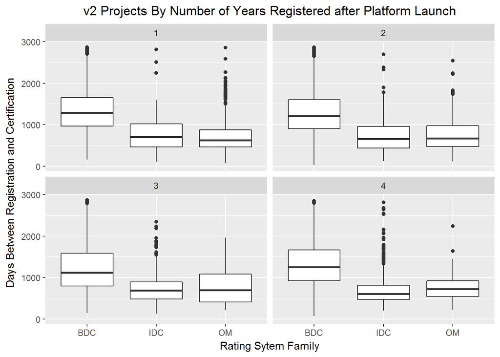

```r
completed_projects_v2 <- subset(completed_projects_v2, completed_projects_v2$RegYear < 5 &
    completed_projects_v2$RegYear > 0)
ggplot(completed_projects_v2, aes(y = SubmittalTime, x = RatingSystemFamily)) + geom_boxplot() +
    facet_wrap(~RegYear) + labs(x = "Rating Sytem Family", y = "Days Between Registration and Certification") +
    ggtitle("v2 Projects By Number of Years Registered after Platform Launch") + theme(plot.title = element_text(hjust = 0.5))
```

```r
completed_projects_v3 <- subset(completed_projects, completed_projects$Platform == "v3")
table(completed_projects_v3$RegYear)
```

```
##
##    1    2    3    4    5    6    7    8
## 2281 3430 3568 3238 2693 2074 1350  622
```

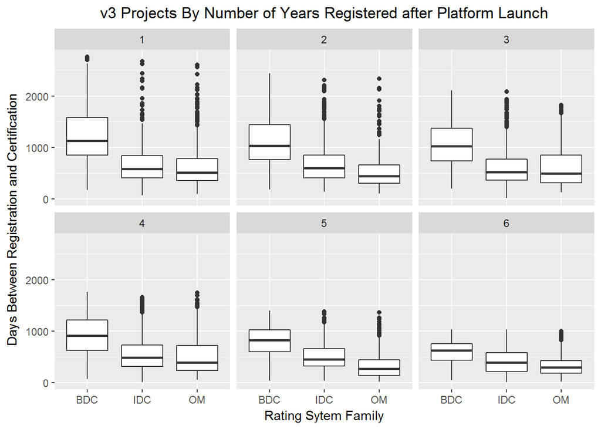

```r
completed_projects_v3 <- subset(completed_projects_v3, completed_projects_v3$RegYear < 7 &
    completed_projects_v3$RegYear > 0)
ggplot(completed_projects_v3, aes(y = SubmittalTime, x = RatingSystemFamily)) + geom_boxplot() +
    facet_wrap(~RegYear) + labs(x = "Rating Sytem Family", y = "Days Between Registration and Certification") +
    ggtitle("v3 Projects By Number of Years Registered after Platform Launch") + theme(plot.title = element_text(hjust = 0.5))
```

```r
completed_projects <- subset(completed_projects, Platform == "v3")
```

Since most projects using the v2 Platform have either been certified or will soon be sunsetted and no longer have the ability to certify, it does not benefit us to make any predictions based on this data. Additionally, there is more than enough v3 Platform project data to do an analyses; therefore, the v2 data will be removed for all inference calculations. Below are the exploratory graphs repeated for the v3 platform only.

```r
#### Graphs based on present assumptions
table(completed_projects$RatingSystemFamily)
```

```
##
##  BDC  IDC   OM
## 9738 5712 3806
```

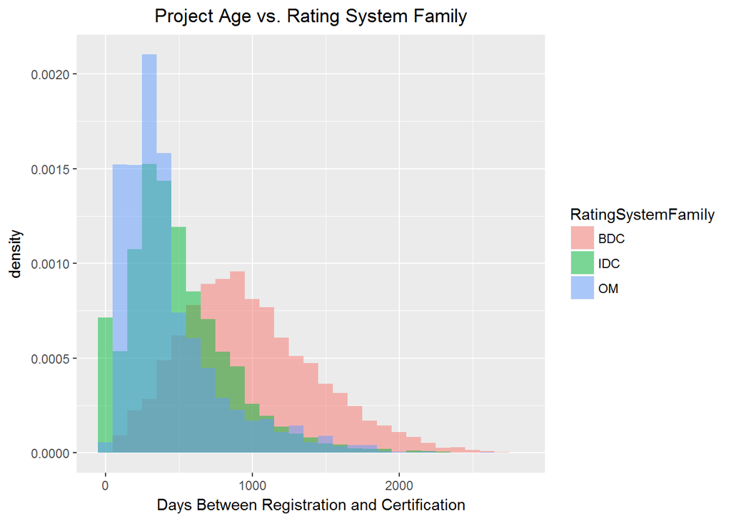

```r
# General Rating System Family histogram
ggplot(completed_projects, aes(x = SubmittalTime, fill = RatingSystemFamily)) + geom_histogram(binwidth = 100,
    alpha = 0.5, position = "identity", aes(y = ..density..)) + labs(x = "Days Between Registration and Certification") +
    ggtitle("Project Age vs. Rating System Family") + theme(plot.title = element_text(hjust = 0.5))
```

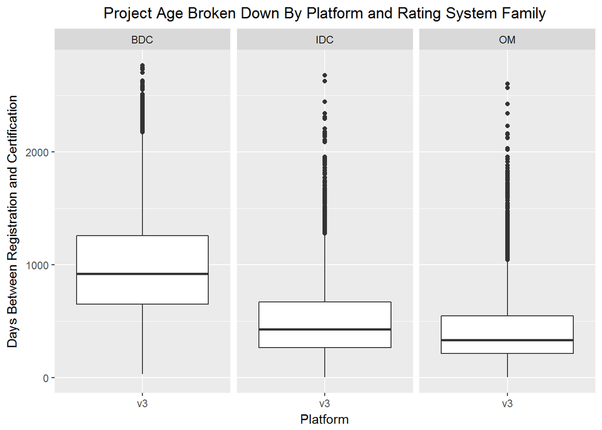

```r
# General Platform ~ Rating System Family boxplot
ggplot(completed_projects, aes(y = SubmittalTime, x = Platform)) + geom_boxplot() + facet_wrap(~RatingSystemFamily) +
    labs(y = "Days Between Registration and Certification") + ggtitle("Project Age Broken Down By Platform and Rating System Family") +
    theme(plot.title = element_text(hjust = 0.5))
```

```r
# Summary Tables
tabledata <- subset(completed_projects, completed_projects$RatingSystemFamily == "BDC")
summary(tabledata$SubmittalTime)
```

```
##    Min. 1st Qu.  Median    Mean 3rd Qu.    Max.
##    34.0   651.0   922.0   980.5  1260.0  2767.0
```

```r
sd(tabledata$SubmittalTime)
```

```
## [1] 457.5326
```

```r
tabledata <- subset(completed_projects, completed_projects$RatingSystemFamily == "IDC")
summary(tabledata$SubmittalTime)
```

```
##    Min. 1st Qu.  Median    Mean 3rd Qu.    Max.
##     4.0   266.0   428.0   499.6   670.0  2679.0
```

```r
sd(tabledata$SubmittalTime)
```

```
## [1] 350.5224
```

```r
tabledata <- subset(completed_projects, completed_projects$RatingSystemFamily == "OM")
summary(tabledata$SubmittalTime)
```

```
##    Min. 1st Qu.  Median    Mean 3rd Qu.    Max.
##     6.0   217.2   336.0   439.7   548.0  2604.0
```

```r
sd(tabledata$SubmittalTime)
```

```
## [1] 349.5398
```

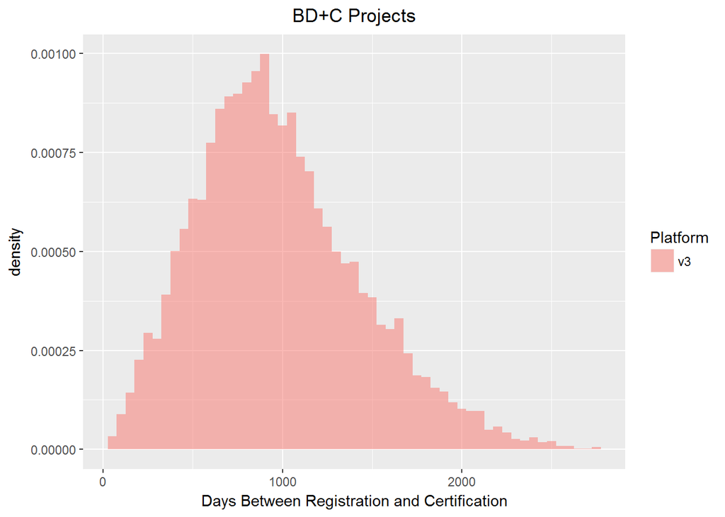

```r
#### Rating System Family Tests
completed_projects_BDC <- subset(completed_projects, completed_projects$RatingSystemFamily ==
    "BDC")
ggplot(completed_projects_BDC, aes(x = SubmittalTime, fill = Platform)) + geom_histogram(binwidth = 50,
    alpha = 0.5, position = "identity", aes(y = ..density..)) + labs(x = "Days Between Registration and Certification") +
    ggtitle("BD+C Projects") + theme(plot.title = element_text(hjust = 0.5))
```

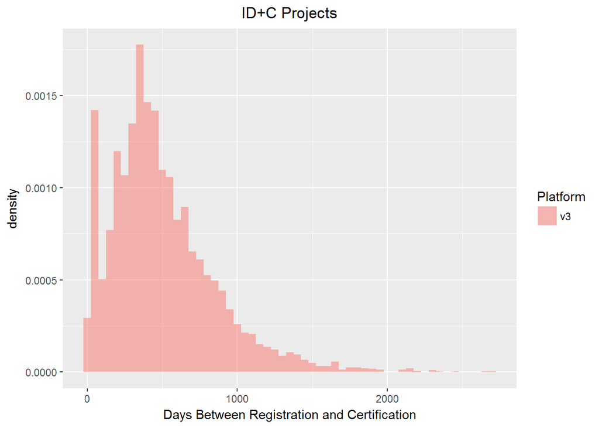

```r
completed_projects_IDC <- subset(completed_projects, completed_projects$RatingSystemFamily ==
    "IDC")
ggplot(completed_projects_IDC, aes(x = SubmittalTime, fill = Platform)) + geom_histogram(binwidth = 50,
    alpha = 0.5, position = "identity", aes(y = ..density..)) + labs(x = "Days Between Registration and Certification") +
    ggtitle("ID+C Projects") + theme(plot.title = element_text(hjust = 0.5))
```

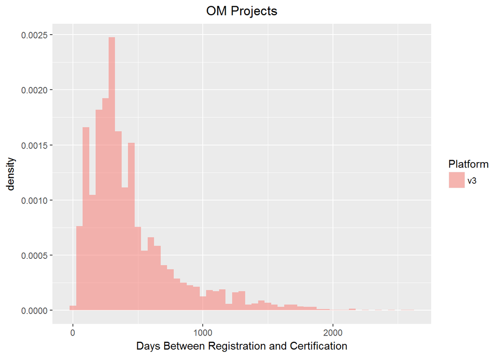

```r
completed_projects_OM <- subset(completed_projects, completed_projects$RatingSystemFamily ==
    "OM")
ggplot(completed_projects_OM, aes(x = SubmittalTime, fill = Platform)) + geom_histogram(binwidth = 50,
    alpha = 0.5, position = "identity", aes(y = ..density..)) + labs(x = "Days Between Registration and Certification") +
    ggtitle("OM Projects") + theme(plot.title = element_text(hjust = 0.5))
```

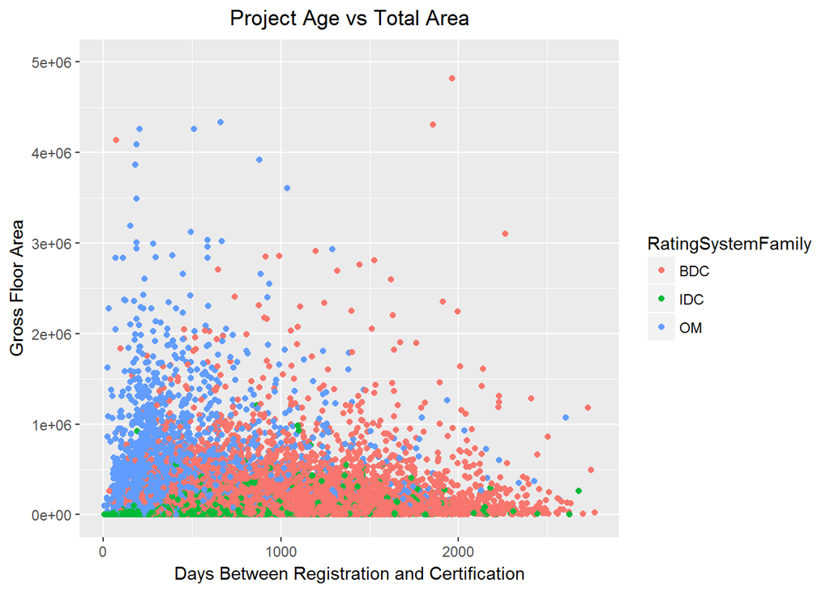

```r
#### Gross floor area vs. submittal time tests

# I have scaled the y axis to exclude some outliers in favor of seeing the main data set
# more clearly

ggplot(completed_projects, aes(y = GrossSqFoot, x = SubmittalTime, color = RatingSystemFamily)) +
    geom_point() + scale_y_continuous(limits = c(0, 5e+06)) + labs(x = "Days Between Registration and Certification",
    y = "Gross Floor Area") + ggtitle("Project Age vs Total Area") + theme(plot.title = element_text(hjust = 0.5))
```

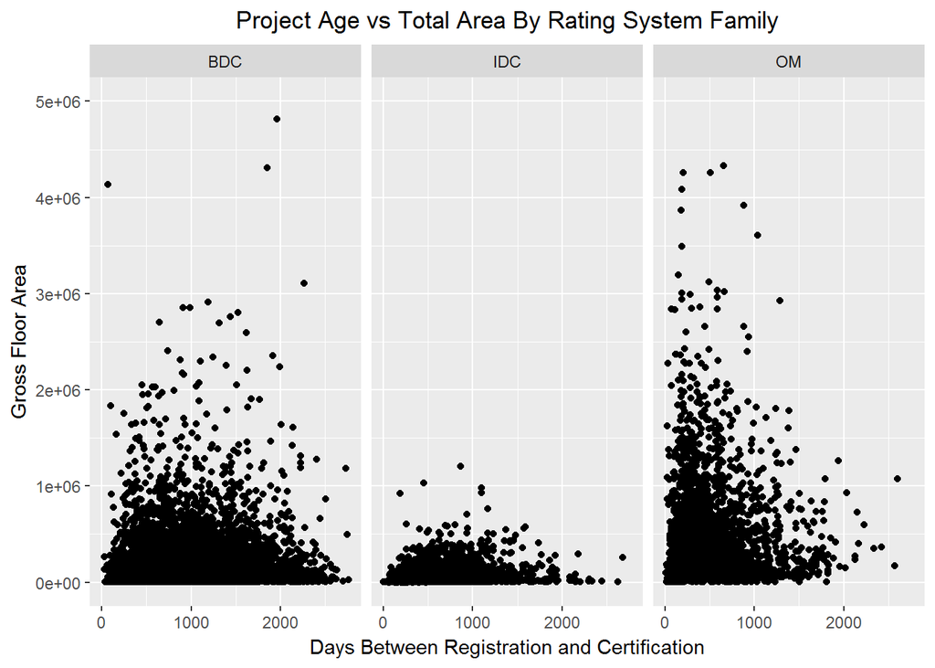

```r
# When a facet wrap is applied, it is a little more clear there may be some association
# with at least one rating system.

ggplot(completed_projects, aes(y = GrossSqFoot, x = SubmittalTime)) + geom_point() + facet_wrap(~RatingSystemFamily) +
    scale_y_continuous(limits = c(0, 5e+06)) + labs(x = "Days Between Registration and Certification",
    y = "Gross Floor Area") + ggtitle("Project Age vs Total Area By Rating System Family") +
    theme(plot.title = element_text(hjust = 0.5))
```

```r
# This is a test to see if project timelines decrease as the time between the registration
# date and the launch date increases Create a data frame of completed v2 projects that are
# at least as old as the v3 launch.  This is so that we know we aren't creating a bias with
# recently registered projects that certified quickly.
completed_projects_v3 <- subset(completed_projects, completed_projects$Platform == "v3")
table(completed_projects_v3$RegYear)
```

```
##
##    1    2    3    4    5    6    7    8
## 2281 3430 3568 3238 2693 2074 1350  622
```

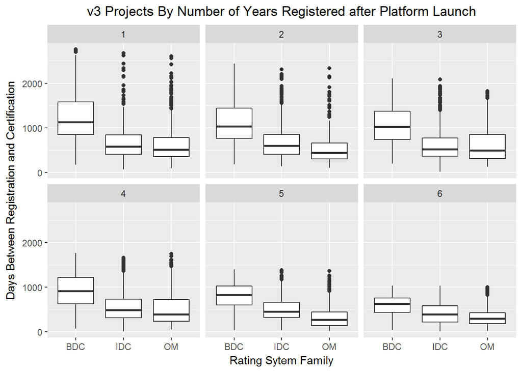

```r
completed_projects_v3 <- subset(completed_projects_v3, completed_projects_v3$RegYear < 7 &
    completed_projects_v3$RegYear > 0)
ggplot(completed_projects_v3, aes(y = SubmittalTime, x = RatingSystemFamily)) + geom_boxplot() +
    facet_wrap(~RegYear) + labs(x = "Rating Sytem Family", y = "Days Between Registration and Certification") +
    ggtitle("v3 Projects By Number of Years Registered after Platform Launch") + theme(plot.title = element_text(hjust = 0.5))
```

### Part 4 - Inference:

Frome the previous section, we can see that it appears the most signinficant difference between groups is the rating system families. Additionally, we will test to see if gross floor area is a significant predictor of the time it takes for a project to certify (submittal time).

#### Analysis of Variance (ANOVA) Test Between Rating System Families.

First, we will test to see if there is a statistically significant difference of at least one of the means between Rating System Families (BDC, IDC, OM). Using an analysis of variace (ANOVA) test, we can evaluate whether the null hypthoesis (${ H }_{ O }$), which assumes there is no difference, can be rejected in favor of the althernative hypothesis (${ H }_{ A }$). These hypothesis can be summarized as follows

$${ H }_{ O }:\quad The\quad mean\quad submittal\quad time\quad is\quad the\quad same\quad across\quad all\quad Rating\quad System\quad Families\\ { H }_{ A }:\quad The\quad mean\quad submittal\quad time\quad for\quad at\quad least\quad one\quad Rating\quad System\quad Family\quad is\quad different$$

In order to do this, we must first verify the following assumptions:

1. The observations are independent within and across groups

Since the data actually represent all current projects, it can be assumed that there is no bias in the sampling because no sampling is being performed. Also, projects can only be in one Rating System Family. Therefore, the obseravations are considered independent.

2. The data within each group are nearly normal

#### BD+C Projects

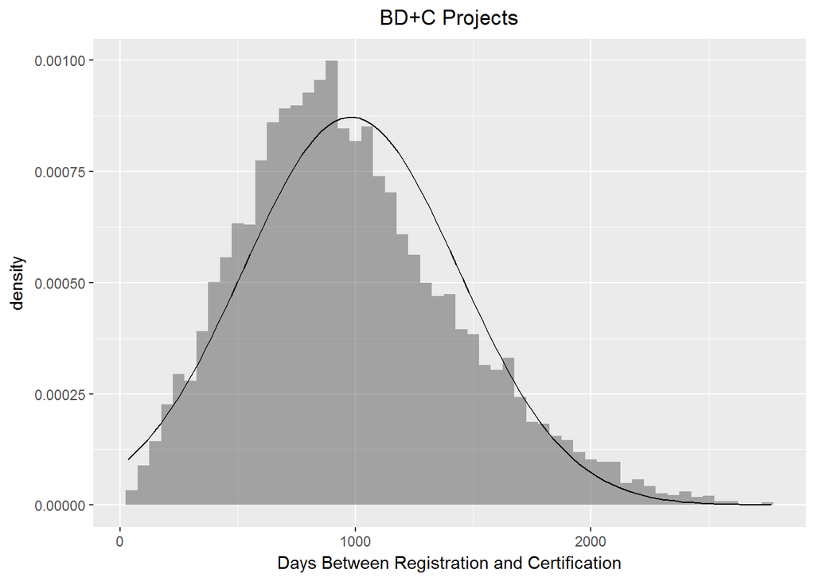

```r
completed_projects_BDC_V3 <- subset(completed_projects_BDC, Platform == "v3")
ggplot(completed_projects_BDC_V3, aes(x = SubmittalTime)) + geom_histogram(binwidth = 50, alpha = 0.5,
    position = "identity", aes(y = ..density..)) + labs(x = "Days Between Registration and Certification") +
    ggtitle("BD+C Projects") + theme(plot.title = element_text(hjust = 0.5)) + stat_function(fun = dnorm,
    color = "black", args = list(mean = mean(completed_projects_BDC_V3$SubmittalTime), sd(completed_projects_BDC_V3$SubmittalTime)))
```

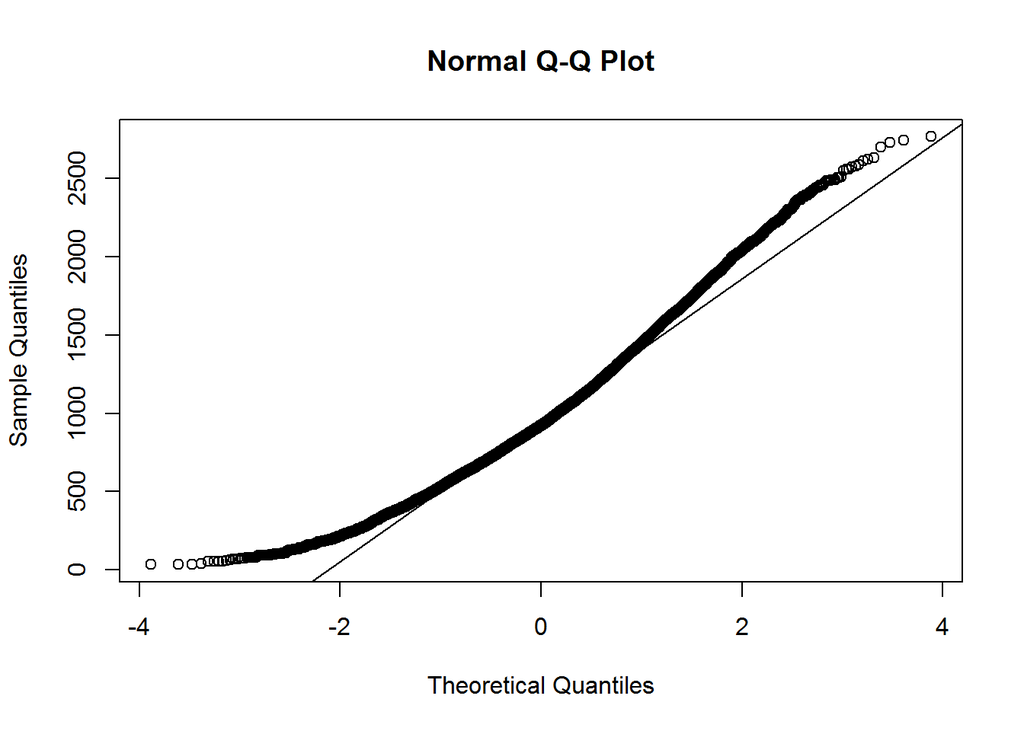

```r
qqnorm(completed_projects_BDC_V3$SubmittalTime)
qqline(completed_projects_BDC_V3$SubmittalTime)
```

#### IDC Projects

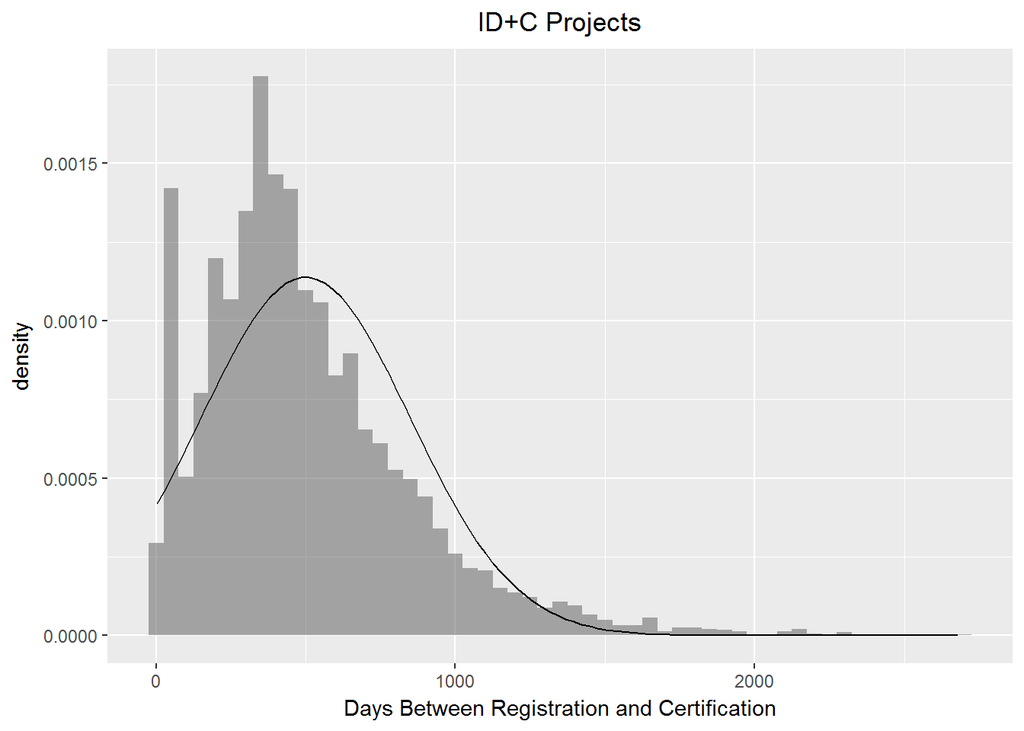

```r
completed_projects_IDC_V3 <- subset(completed_projects_IDC, Platform == "v3")
ggplot(completed_projects_IDC_V3, aes(x = SubmittalTime)) + geom_histogram(binwidth = 50, alpha = 0.5,
    position = "identity", aes(y = ..density..)) + labs(x = "Days Between Registration and Certification") +
    ggtitle("ID+C Projects") + theme(plot.title = element_text(hjust = 0.5)) + stat_function(fun = dnorm,
    color = "black", args = list(mean = mean(completed_projects_IDC_V3$SubmittalTime), sd(completed_projects_IDC_V3$SubmittalTime)))
```

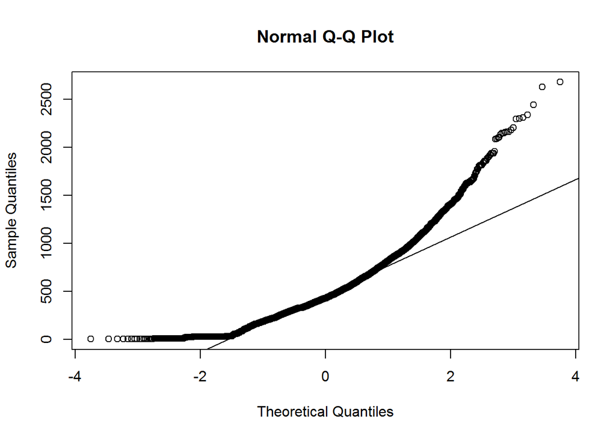

```r
qqnorm(completed_projects_IDC_V3$SubmittalTime)
qqline(completed_projects_IDC_V3$SubmittalTime)
```

#### OM Projects

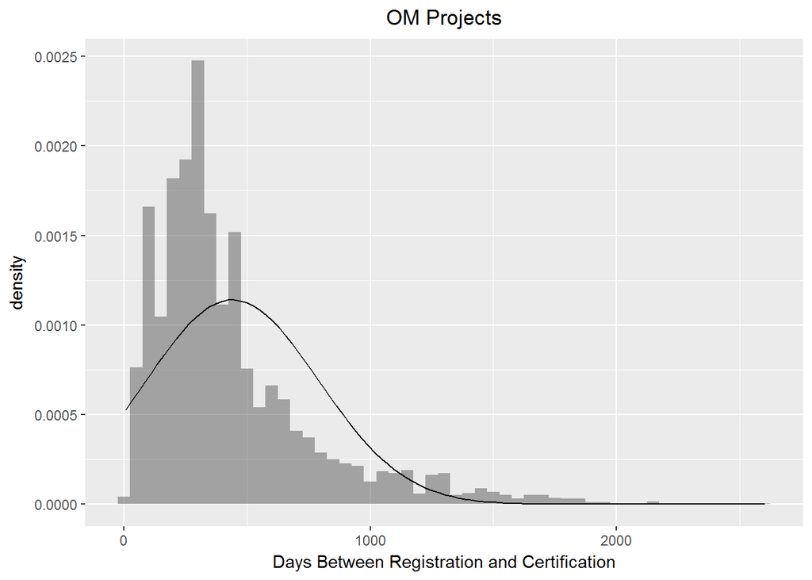

```r
completed_projects_OM_V3 <- subset(completed_projects_OM, Platform == "v3")
ggplot(completed_projects_OM_V3, aes(x = SubmittalTime)) + geom_histogram(binwidth = 50, alpha = 0.5,
    position = "identity", aes(y = ..density..)) + labs(x = "Days Between Registration and Certification") +
    ggtitle("OM Projects") + theme(plot.title = element_text(hjust = 0.5)) + stat_function(fun = dnorm,
    color = "black", args = list(mean = mean(completed_projects_OM_V3$SubmittalTime), sd(completed_projects_OM_V3$SubmittalTime)))
```

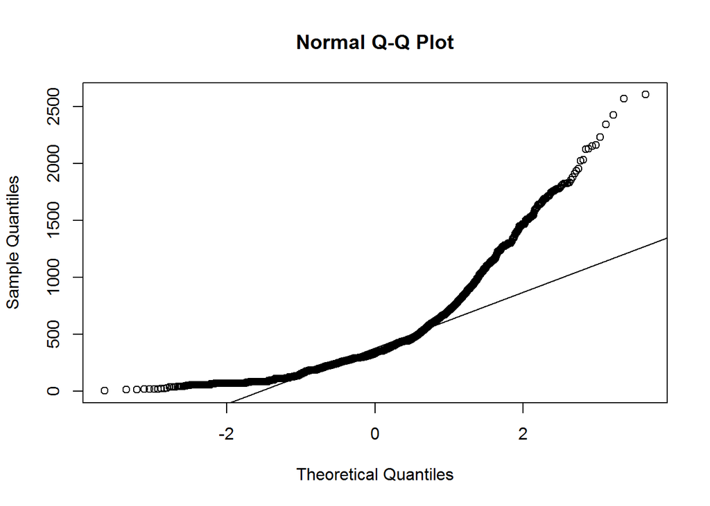

```r
qqnorm(completed_projects_OM_V3$SubmittalTime)
qqline(completed_projects_OM_V3$SubmittalTime)
```

3. The variability across the groups is about equal.

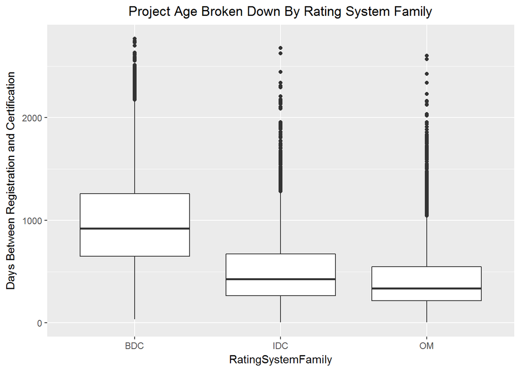

```r
completed_projects_V3 <- subset(completed_projects, Platform == "v3")
ggplot(completed_projects_V3, aes(y = SubmittalTime, x = RatingSystemFamily)) + geom_boxplot() +
    labs(y = "Days Between Registration and Certification") + ggtitle("Project Age Broken Down By Rating System Family") +
    theme(plot.title = element_text(hjust = 0.5))
```

We will now perform an ANOVA test. For this analysis, we will use a significance level of $\alpha = 0.05$. This corresponds to an assumption that 95% of the time, we will not reject the null hypothesis (i.e. no difference) when it is true and 5% of the time we will, which is considered a Type I error.

```r
RSF_aov <- aov(SubmittalTime ~ RatingSystemFamily, data = completed_projects_V3)
summary(RSF_aov)
```

```
##                       Df    Sum Sq   Mean Sq F value Pr(>F)
## RatingSystemFamily     2 1.235e+09 617559283    3710 <2e-16 ***
## Residuals          19253 3.205e+09    166461
## ---
## Signif. codes:  0 '***' 0.001 '**' 0.01 '*' 0.05 '.' 0.1 ' ' 1
```

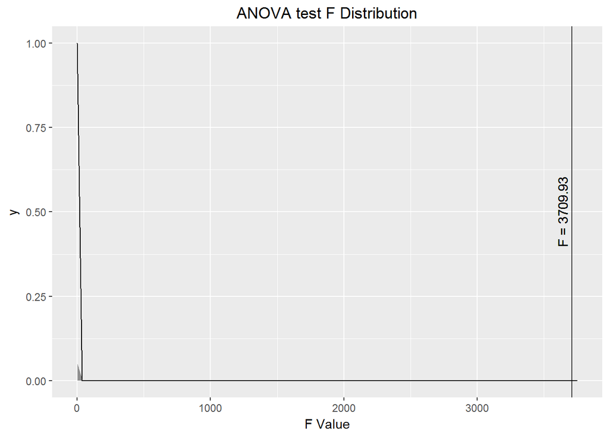

```r
lb <- 0
ub <- 3750
f_value <- summary(RSF_aov)[[1]][["F value"]][1]
f1 <- qf(p = (1 - 0.05), df1 = summary(RSF_aov)[[1]][[1]][1], df2 = summary(RSF_aov)[[1]][[1]][2])
pick_line1 <- round(f_value, digits = 2)
ggplot(data.frame(x = c(lb, ub)), aes(x = x)) + stat_function(fun = df, args = list(df1 = summary(RSF_aov)[[1]][[1]][1],
    df2 = summary(RSF_aov)[[1]][[1]][2])) + stat_function(fun = df, args = list(df1 = summary(RSF_aov)[[1]][[1]][1],
    df2 = summary(RSF_aov)[[1]][[1]][2]), xlim = c(f1, ub), geom = "area", alpha = 0.5) + geom_vline(xintercept = pick_line1,
    color = "black", alpha = 0.75) + geom_text(aes(x = pick_line1, y = 0.5, label = sprintf("F = %s\n",
    pick_line1)), color = "black", angle = 90) + labs(x = "F Value") + ggtitle("ANOVA test F Distribution") +
    theme(plot.title = element_text(hjust = 0.5))
```

Using a confidence level of 95%, we can see that there is sufficient evidence to reject the null hypothesis since the anova test has returned a p-value of 2e-16, which is much less than 0.05. Therefore we reject the hypothesis that the average time between registration and certification (submittal time) is equal.

Now that we know there is a difference of one of the means, we can perform individual pairwise t-tests to determine which means are statistically significant from each other. Since we are performing multiple comparisons across groups, it is necessary to implement a Bonferroni correction so that the Type I error rate is not increased. This is calculated by taking the significance level ($\alpha = 0.05$) and dividing it by the number of groups (3).

```r
bonf_alpha <- 0.05/3
```

We will now test each project against each other using two-sample t-tests.

```r
# BDC vs OM
(BDC_vs_OM_t <- t.test(completed_projects_BDC_V3$SubmittalTime, completed_projects_OM_V3$SubmittalTime,
    conf.level = (1 - bonf_alpha)))
```

```
##
##  Welch Two Sample t-test
##
## data:  completed_projects_BDC_V3$SubmittalTime and completed_projects_OM_V3$SubmittalTime
## t = 73.869, df = 9025.7, p-value < 2.2e-16
## alternative hypothesis: true difference in means is not equal to 0
## 98.33333 percent confidence interval:
##  523.2733 558.3329
## sample estimates:
## mean of x mean of y
##  980.5178  439.7147
```

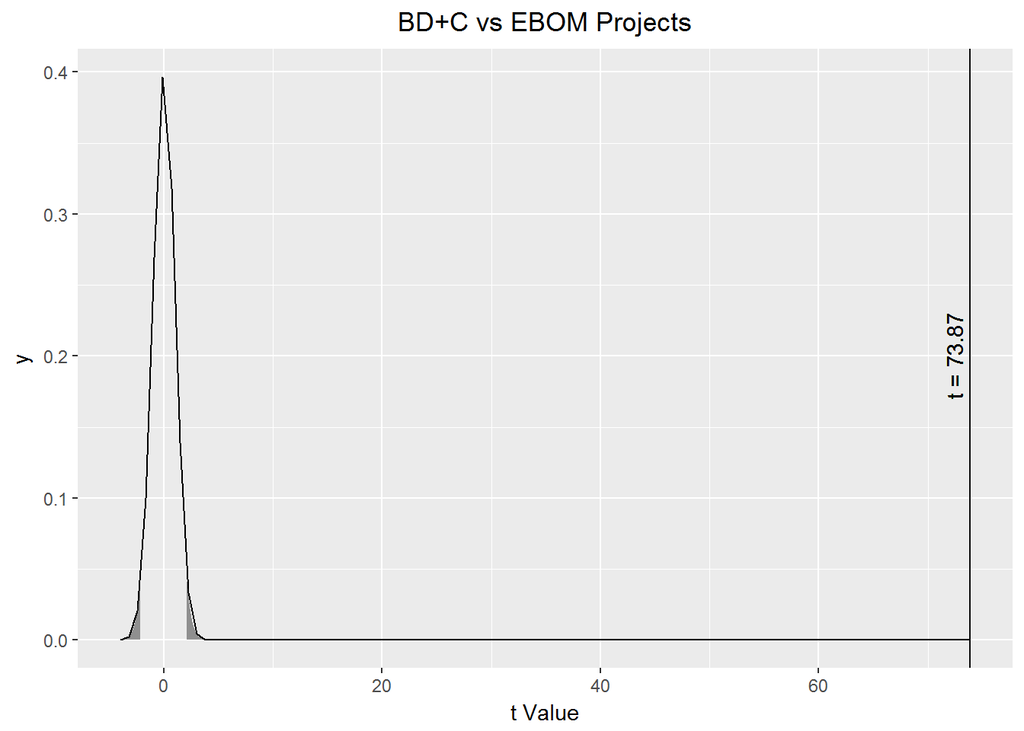

```r
lb <- -4
ub <- 4
t_value <- BDC_vs_OM_t[[1]]
t1 <- qt(p = bonf_alpha, df = BDC_vs_OM_t[[2]])
t2 <- qt(p = 1 - bonf_alpha, df = BDC_vs_OM_t[[2]])
pick_line1 <- round(t_value, digits = 2)
ggplot(data.frame(x = c(lb, ub)), aes(x = x)) + stat_function(fun = dt, args = list(df = BDC_vs_OM_t[[2]])) +
    stat_function(fun = dt, args = list(df = BDC_vs_OM_t[[2]]), xlim = c(lb, t1), geom = "area",
        alpha = 0.5) + geom_vline(xintercept = pick_line1, color = "black", alpha = 0.75) +
    stat_function(fun = dt, args = list(df = BDC_vs_OM_t[[2]]), xlim = c(t2, ub), geom = "area",
        alpha = 0.5) + geom_vline(xintercept = pick_line1, color = "black", alpha = 0.75) +
    geom_text(aes(x = pick_line1, y = 0.2, label = sprintf("t = %s\n", pick_line1)), color = "black",
        angle = 90) + labs(x = "t Value") + ggtitle("BD+C vs EBOM Projects") + theme(plot.title = element_text(hjust = 0.5))
```

```r
# BDC vs IDC
(BDC_vs_IDC_t <- t.test(completed_projects_BDC_V3$SubmittalTime, completed_projects_IDC_V3$SubmittalTime,
    conf.level = (1 - bonf_alpha)))
```

```
##
##  Welch Two Sample t-test
##
## data:  completed_projects_BDC_V3$SubmittalTime and completed_projects_IDC_V3$SubmittalTime
## t = 73.337, df = 14396, p-value < 2.2e-16
## alternative hypothesis: true difference in means is not equal to 0
## 98.33333 percent confidence interval:
##  465.2377 496.6406
## sample estimates:
## mean of x mean of y
##  980.5178  499.5786
```

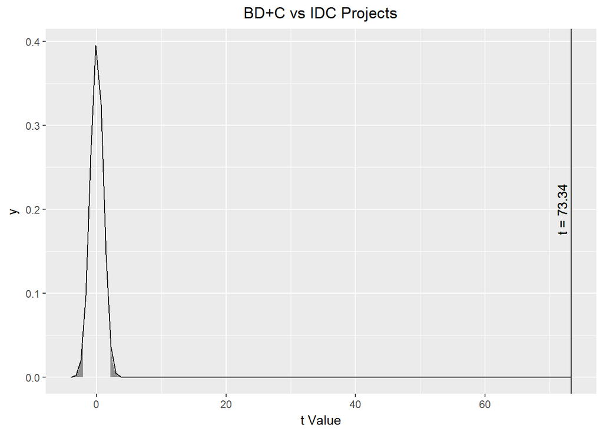

```r
lb <- -4
ub <- 4
t_value <- BDC_vs_IDC_t[[1]]
t1 <- qt(p = bonf_alpha, df = BDC_vs_IDC_t[[2]])
t2 <- qt(p = 1 - bonf_alpha, df = BDC_vs_IDC_t[[2]])
pick_line1 <- round(t_value, digits = 2)
ggplot(data.frame(x = c(lb, ub)), aes(x = x)) + stat_function(fun = dt, args = list(df = BDC_vs_IDC_t[[2]])) +
    stat_function(fun = dt, args = list(df = BDC_vs_IDC_t[[2]]), xlim = c(lb, t1), geom = "area",
        alpha = 0.5) + geom_vline(xintercept = pick_line1, color = "black", alpha = 0.75) +
    stat_function(fun = dt, args = list(df = BDC_vs_IDC_t[[2]]), xlim = c(t2, ub), geom = "area",
        alpha = 0.5) + geom_vline(xintercept = pick_line1, color = "black", alpha = 0.75) +
    geom_text(aes(x = pick_line1, y = 0.2, label = sprintf("t = %s\n", pick_line1)), color = "black",
        angle = 90) + labs(x = "t Value") + ggtitle("BD+C vs IDC Projects") + theme(plot.title = element_text(hjust = 0.5))
```

```r
# OM vs IDC
(OM_vs_IDC_t <- t.test(completed_projects_OM_V3$SubmittalTime, completed_projects_IDC_V3$SubmittalTime,
    conf.level = (1 - bonf_alpha)))
```

```
##
##  Welch Two Sample t-test
##
## data:  completed_projects_OM_V3$SubmittalTime and completed_projects_IDC_V3$SubmittalTime
## t = -8.1759, df = 8168.9, p-value = 3.378e-16
## alternative hypothesis: true difference in means is not equal to 0
## 98.33333 percent confidence interval:
##  -77.39626 -42.33163
## sample estimates:
## mean of x mean of y
##  439.7147  499.5786
```

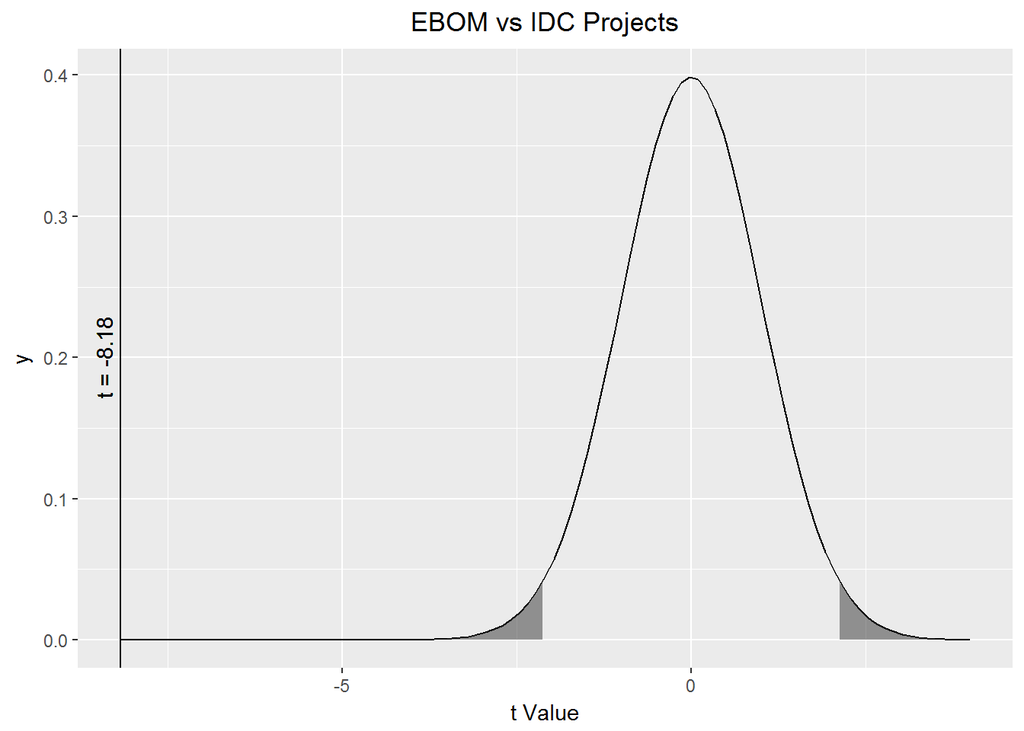

```r
lb <- -4
ub <- 4
t_value <- OM_vs_IDC_t[[1]]
t1 <- qt(p = bonf_alpha, df = OM_vs_IDC_t[[2]])
t2 <- qt(p = 1 - bonf_alpha, df = OM_vs_IDC_t[[2]])
pick_line1 <- round(t_value, digits = 2)
ggplot(data.frame(x = c(lb, ub)), aes(x = x)) + stat_function(fun = dt, args = list(df = OM_vs_IDC_t[[2]])) +
    stat_function(fun = dt, args = list(df = OM_vs_IDC_t[[2]]), xlim = c(lb, t1), geom = "area",
        alpha = 0.5) + geom_vline(xintercept = pick_line1, color = "black", alpha = 0.75) +
    stat_function(fun = dt, args = list(df = OM_vs_IDC_t[[2]]), xlim = c(t2, ub), geom = "area",
        alpha = 0.5) + geom_vline(xintercept = pick_line1, color = "black", alpha = 0.75) +
    geom_text(aes(x = pick_line1, y = 0.2, label = sprintf("t = %s\n", pick_line1)), color = "black",
        angle = 90) + labs(x = "t Value") + ggtitle("EBOM vs IDC Projects") + theme(plot.title = element_text(hjust = 0.5))
```

As can be seen from the pariwise t-tests, it has been determined that we are 95% confident that the mean submittal time between Rating System Famiilies is different between all groups (BD+C, ID+C, and OM).

Now, there are not many numerical values that can be used as predictors of how long it will take a project to certify. Note, attributes such as the number of points achieved and certification level are only known after a project has certified; therefore, have limited value. One possible numerical indicator of submittal time that can be used in the gross floor area of the project. We will now use this predictor to determine a least squares linear regerssion line to predict the response variable of submittal time. Due to the large differences in the maximum and minimum values, a log translation will be applied to the data. Also, since we have already determined that each Rating System Family has significantly different submittal times, we will perform separate linear regression analsyses for BD+C, ID+C, and OM.

#### Generate Linear Regression Models and Graphs

```r
# BDC
gf_lm_BDC_V3 <- lm(SubmittalTime ~ log(GrossSqFoot), data = completed_projects_BDC_V3)
summary(gf_lm_BDC_V3)
```

```
##
## Call:
## lm(formula = SubmittalTime ~ log(GrossSqFoot), data = completed_projects_BDC_V3)
##
## Residuals:
##      Min       1Q   Median       3Q      Max
## -1061.72  -324.27   -54.04   274.19  1815.36
##
## Coefficients:
##                  Estimate Std. Error t value Pr(>|t|)
## (Intercept)       588.700     35.044   16.80   <2e-16 ***
## log(GrossSqFoot)   35.709      3.166   11.28   <2e-16 ***
## ---
## Signif. codes:  0 '***' 0.001 '**' 0.01 '*' 0.05 '.' 0.1 ' ' 1
##
## Residual standard error: 454.6 on 9736 degrees of freedom
## Multiple R-squared:  0.0129, Adjusted R-squared:  0.0128
## F-statistic: 127.2 on 1 and 9736 DF,  p-value: < 2.2e-16
```

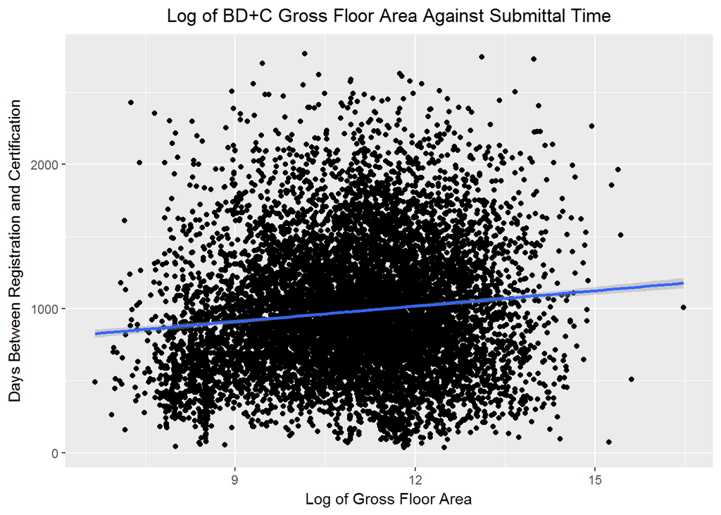

```r
ggplot(completed_projects_BDC_V3, aes(y = SubmittalTime, x = log(GrossSqFoot))) + geom_point() +
    geom_smooth(method = lm, fullrange = TRUE) + labs(x = "Log of Gross Floor Area", y = "Days Between Registration and Certification") +
    ggtitle("Log of BD+C Gross Floor Area Against Submittal Time") + theme(plot.title = element_text(hjust = 0.5))
```

```r
# IDC
gf_lm_IDC_V3 <- lm(SubmittalTime ~ log(GrossSqFoot), data = completed_projects_IDC_V3)
summary(gf_lm_IDC_V3)
```

```
##
## Call:
## lm(formula = SubmittalTime ~ log(GrossSqFoot), data = completed_projects_IDC_V3)
##
## Residuals:
##    Min     1Q Median     3Q    Max
## -761.1 -221.5  -67.4  134.9 2223.8
##
## Coefficients:
##                  Estimate Std. Error t value Pr(>|t|)
## (Intercept)       -514.84      27.71  -18.58   <2e-16 ***
## log(GrossSqFoot)   106.64       2.88   37.03   <2e-16 ***
## ---
## Signif. codes:  0 '***' 0.001 '**' 0.01 '*' 0.05 '.' 0.1 ' ' 1
##
## Residual standard error: 314.8 on 5710 degrees of freedom
## Multiple R-squared:  0.1936, Adjusted R-squared:  0.1935
## F-statistic:  1371 on 1 and 5710 DF,  p-value: < 2.2e-16
```

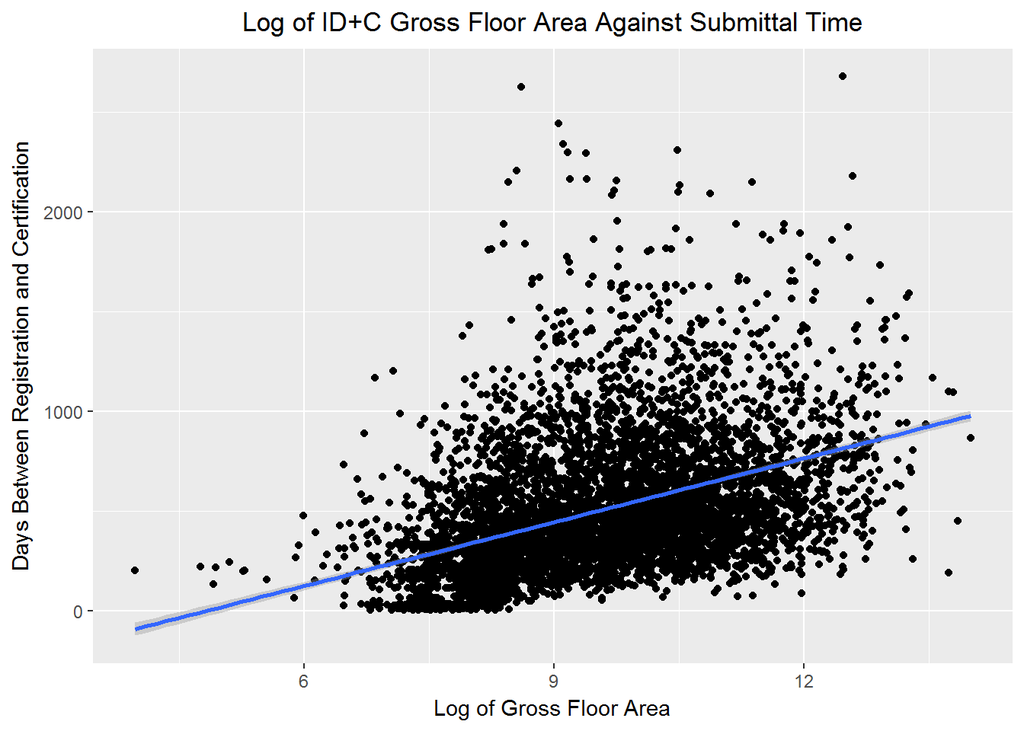

```r
ggplot(completed_projects_IDC_V3, aes(y = SubmittalTime, x = log(GrossSqFoot))) + geom_point() +
    geom_smooth(method = lm, fullrange = TRUE) + labs(x = "Log of Gross Floor Area", y = "Days Between Registration and Certification") +
    ggtitle("Log of ID+C Gross Floor Area Against Submittal Time") + theme(plot.title = element_text(hjust = 0.5))
```

```r
# OM
gf_lm_OM_V3 <- lm(SubmittalTime ~ log(GrossSqFoot), data = completed_projects_OM_V3)
summary(gf_lm_OM_V3)
```

```
##
## Call:
## lm(formula = SubmittalTime ~ log(GrossSqFoot), data = completed_projects_OM_V3)
##
## Residuals:
##     Min      1Q  Median      3Q     Max
## -530.08 -206.66 -111.60   90.03 2129.17
##
## Coefficients:
##                  Estimate Std. Error t value Pr(>|t|)
## (Intercept)      -119.826     45.537  -2.631  0.00854 **
## log(GrossSqFoot)   46.444      3.752  12.380  < 2e-16 ***
## ---
## Signif. codes:  0 '***' 0.001 '**' 0.01 '*' 0.05 '.' 0.1 ' ' 1
##
## Residual standard error: 342.7 on 3804 degrees of freedom
## Multiple R-squared:  0.03873,    Adjusted R-squared:  0.03848
## F-statistic: 153.3 on 1 and 3804 DF,  p-value: < 2.2e-16
```